# Predict431-TS1

It appears that the lowest RMSE was within tthe Multiplicative and Damped model, which fit the data best

```r
accuracy(fit_multi)
```

```
##                      ME    RMSE      MAE        MPE     MAPE      MASE
## Training set -0.9498442 14.8295 10.96716 -0.8150922 4.271167 0.4050069
##                   ACF1
## Training set 0.2223887
```

```r
accuracy(fit_multi_damped)
```

```
##                     ME     RMSE      MAE        MPE     MAPE      MASE
## Training set 0.9123468 14.44801 10.64909 0.07071844 4.064322 0.3932608
##                    ACF1
## Training set 0.01740636
```

```r
accuracy(fit_multi_exp_damped)
```

```
##                     ME     RMSE      MAE        MPE     MAPE      MASE
## Training set 0.7230142 14.45533 10.72791 0.03798703 4.090931 0.3961716
##                    ACF1
## Training set 0.01218167
```

4. Time series models 2 (1 point) Use the monthly Australian short-term overseas visitors data, May 1985 - April 2005 to ???t each of the following models to the same data:
1. A multiplicative Holt-Winters’ method;

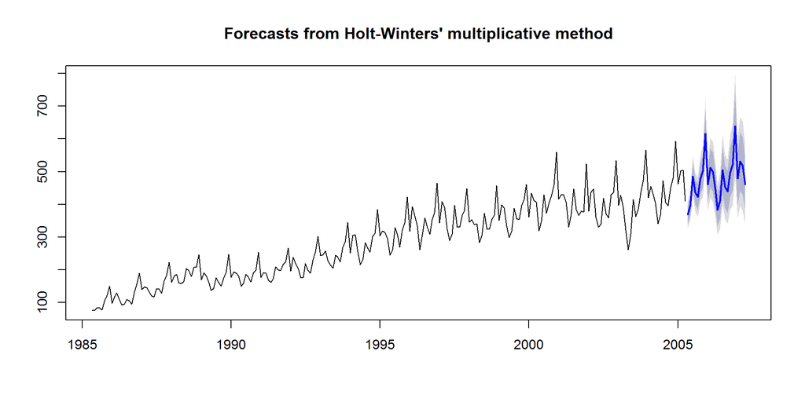

```r
fit_multi <- hw(aust,seasonal="multiplicative")
plot(fit_multi)
```

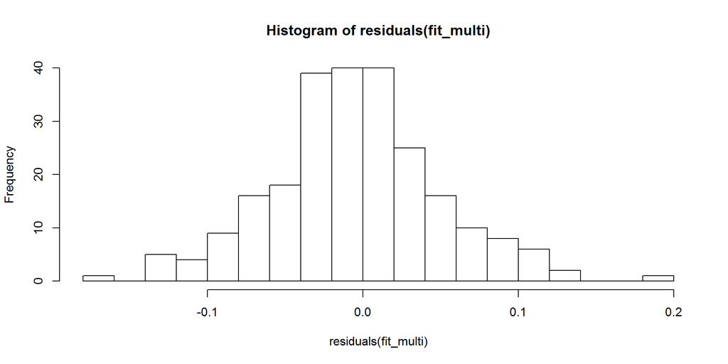

```r
hist(residuals(fit_multi),nclass=20)
```

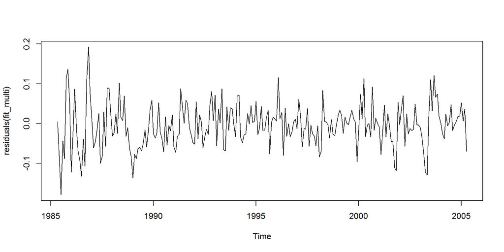

```r
plot(residuals(fit_multi))
```

```r
accuracy(fit_multi)
```

```
##                      ME    RMSE      MAE        MPE     MAPE      MASE
## Training set -0.9498442 14.8295 10.96716 -0.8150922 4.271167 0.4050069
##                   ACF1
## Training set 0.2223887
```

2. An ETS model;

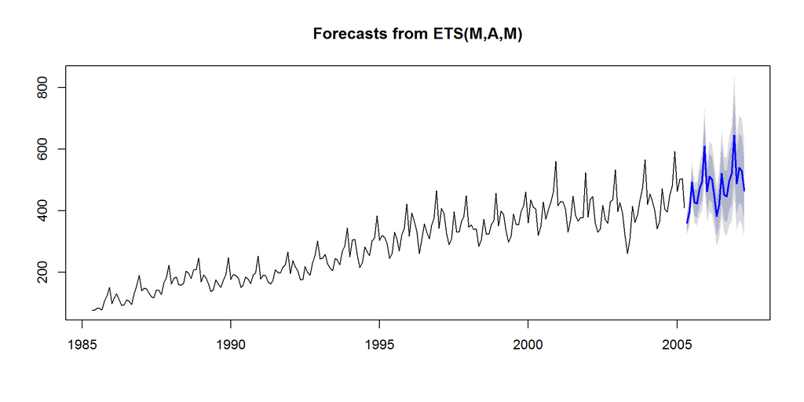

```r
fit_mam <- ets(visitors, model="ZZZ")
plot(forecast(fit_mam))
```

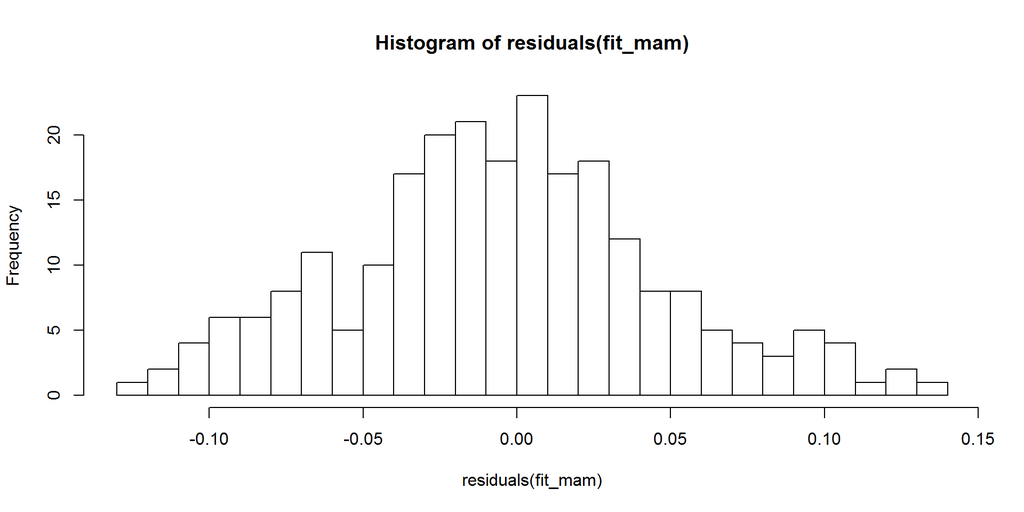

```r
hist(residuals(fit_mam),nclass=20)
```

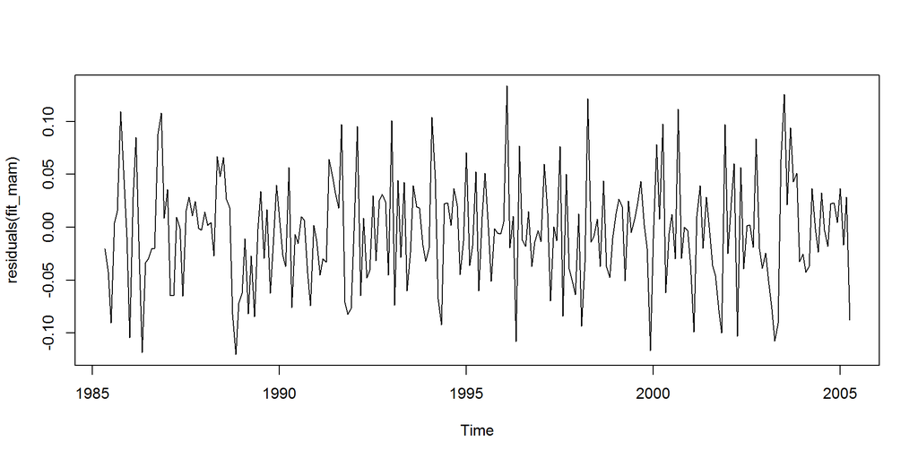

```r
plot(residuals(fit_mam))
```

```r
accuracy(fit_mam)
```

```
##                     ME     RMSE      MAE        MPE     MAPE      MASE
## Training set -1.536043 15.86105 11.53405 -0.7017724 4.076346 0.4259416
##                      ACF1
## Training set -0.004687451
```

3. An additive ETS model applied to a Box-Cox transformed series;

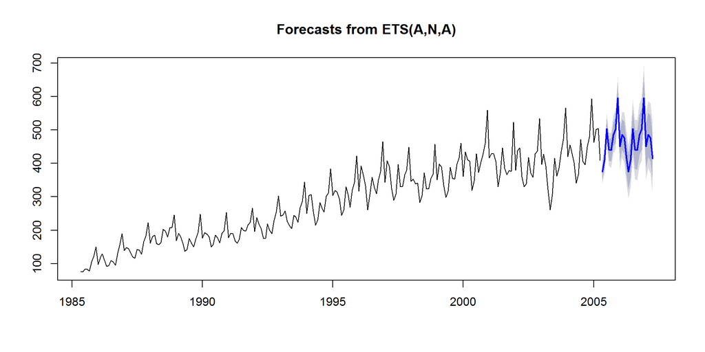

```r
fit_ana_box <- ets(visitors,additive.only=TRUE,lambda=TRUE)
plot(forecast(fit_ana_box))
```

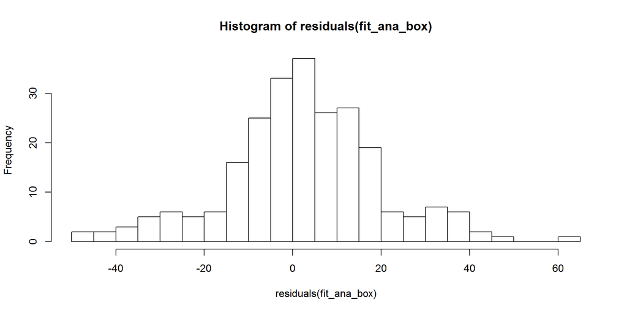

```r
hist(residuals(fit_ana_box),nclass=20)
```

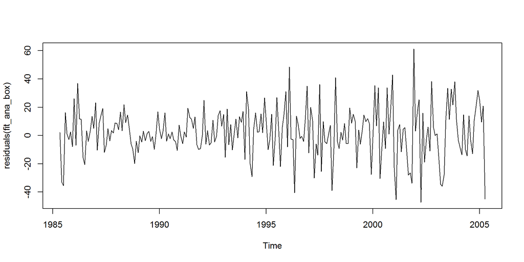

```r
plot(residuals(fit_ana_box))
```

```r
accuracy(fit_ana_box)
```

```
##                    ME     RMSE      MAE       MPE     MAPE      MASE
## Training set 2.346807 17.51126 13.18528 0.5506054 5.103531 0.4869199
##                    ACF1
## Training set 0.02105629
```

4. A seasonal naive method applied to the Box-Cox transformed series;

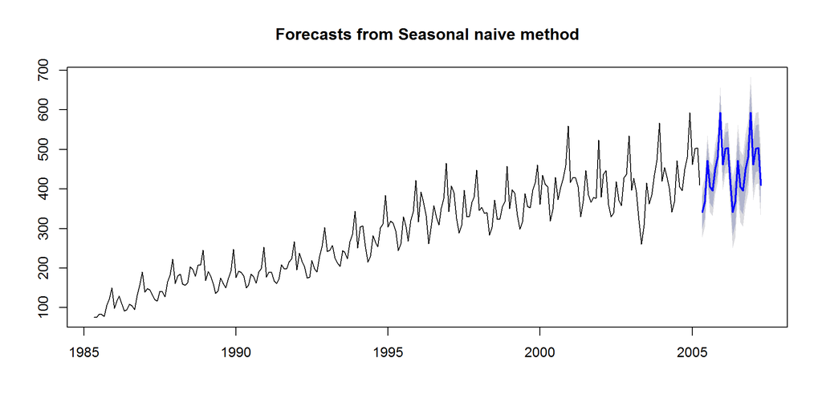

```r
fit_naive <- snaive(visitors,lambda=TRUE)
plot(forecast(fit_naive))
```

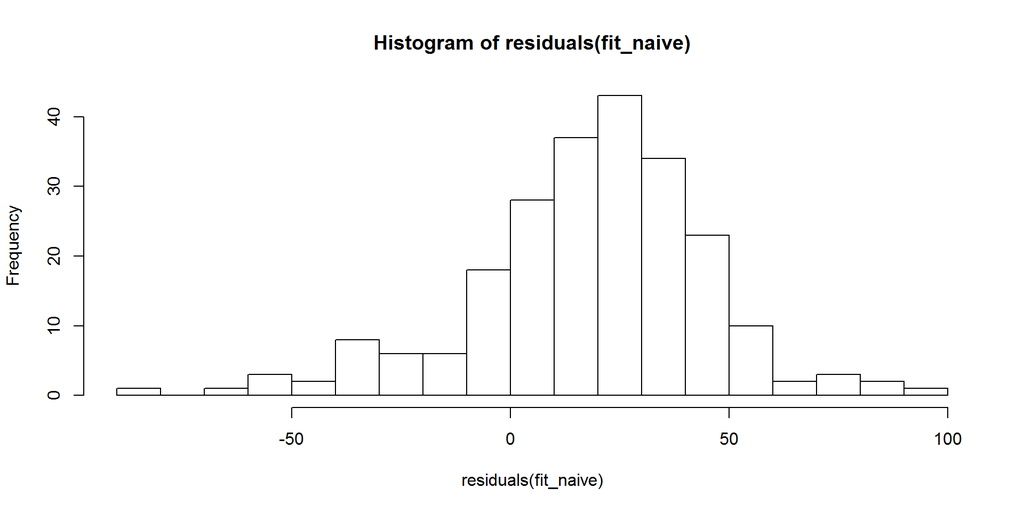

```r
hist(residuals(fit_naive),nclass=20)
```

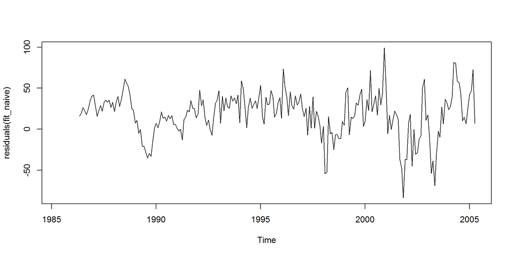

```r
plot(residuals(fit_naive))
```

```r
accuracy(fit_naive)
```

```
##                    ME     RMSE      MAE      MPE     MAPE MASE      ACF1
## Training set 18.22368 32.56941 27.07895 7.011798 10.12935    1 0.6600405
```

5. An STL decomposition applied to the Box-Cox transformed data followed by an ETS model applied to the seasonally adjusted (transformed) data.

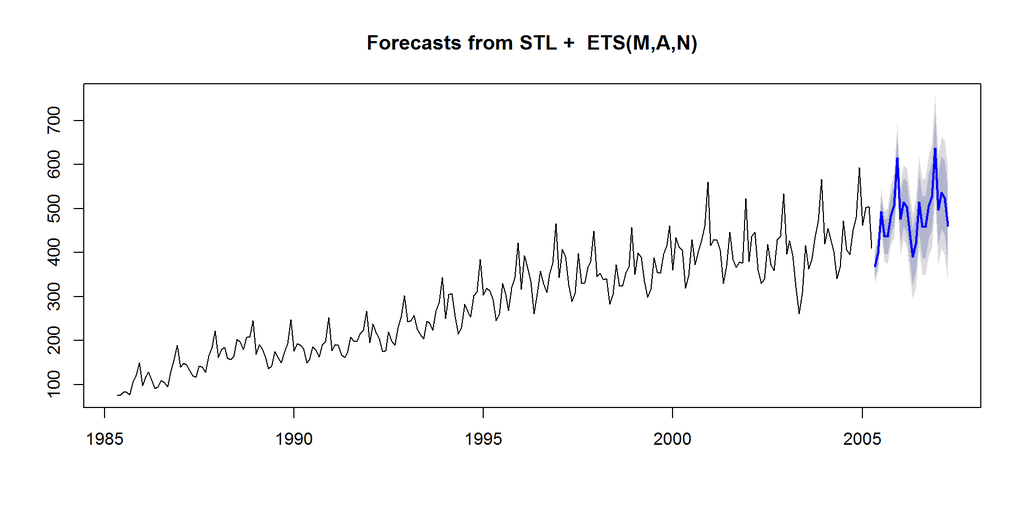

```r
fit_stld <- stlf(visitors,method="ets",lambda=TRUE)
plot(forecast(fit_stld))
```

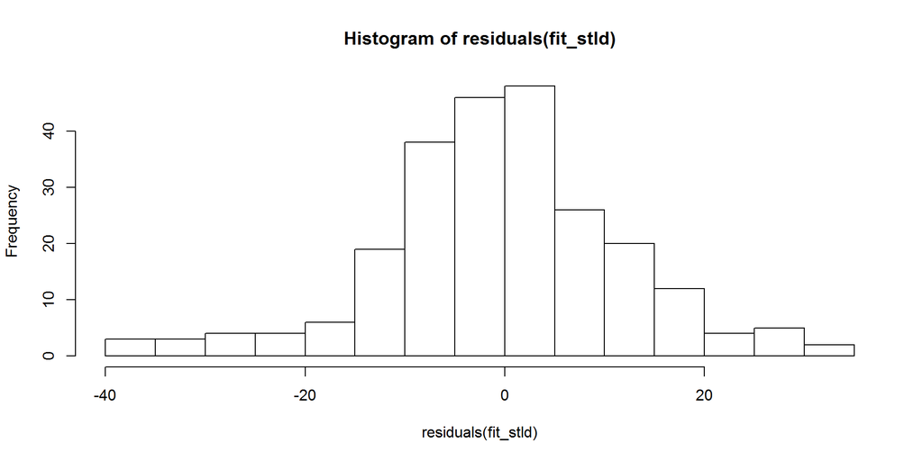

```r
hist(residuals(fit_stld),nclass=20)
```

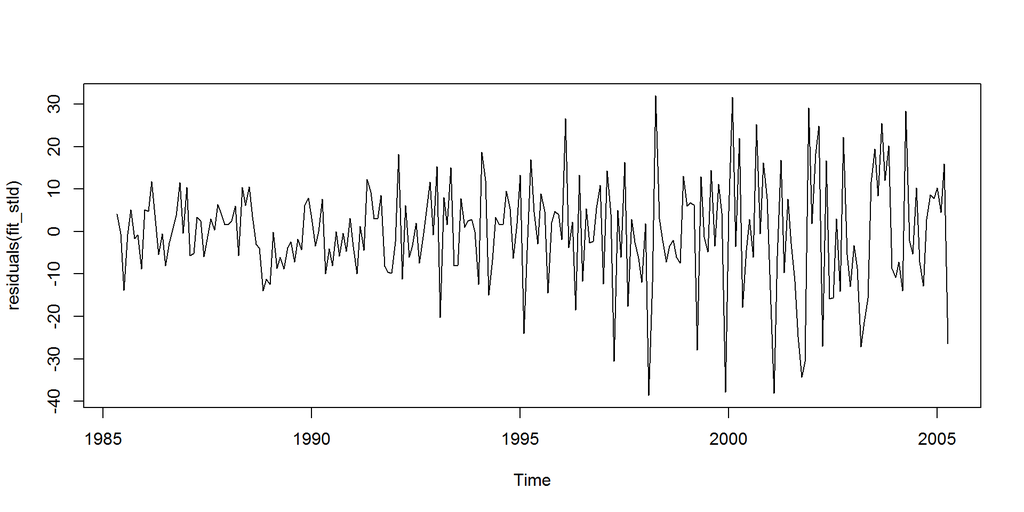

```r
plot(residuals(fit_stld))
```

```r
accuracy(fit_stld)
```

```
##                      ME     RMSE      MAE       MPE     MAPE      MASE
## Training set -0.3615751 12.17064 9.129055 -0.226499 3.252608 0.3371274
##                     ACF1
## Training set -0.02051013
```

6. For each model, look at the residual diagnostics and compare the forecasts for the next two years. Which do you prefer and why?

Looking through the forecasts, I’d rule out model 3 and 4 as the growth does not seem to match the upward trend. The residuals on the naive model in particular do not look normal or random. Although the RSME fit is best for the last model, the residual pattern does not look random (exhibits heteroschedascity). Therefore, I would choose the second model (ETS MAM) as it looks like the best balance of forecast quality, RMSE score, and no apparent issues in the residual diagnostics.

5. Report (1 point) For each data set, provide an summary from which an interested party can take action. Use the appropriate plots and statistics needed to support your recommendations.